# Assignment 3

Evan Blosser

Thursday, July 27, 2023

# Questions{16/16}

## Q 1

### b

It can be observed below that this does follow an exponential distribution with $\beta =95$:

```r
phishing <- read.csv(file = "PHISHING.csv")
summary(phishing)
```

```
##     INTTIME
##  Min.   :  1.862
##  1st Qu.: 30.657
##  Median : 70.876
##  Mean   : 95.524
##  3rd Qu.:133.197
##  Max.   :513.517
```

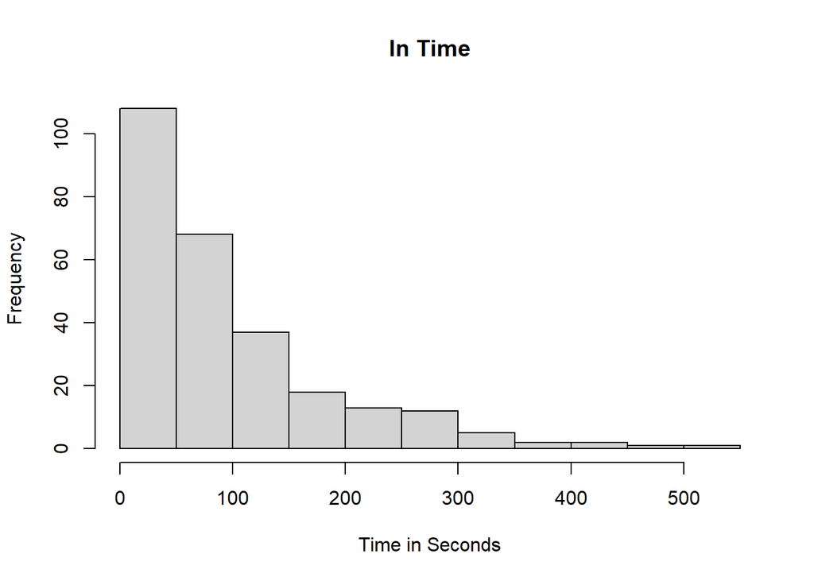

```r
hist(phishing$INTTIME, main="In Time",xlab="Time in Seconds")
```

## Q 2

### a

Given $\alpha = 3$ & $\beta = 0.07$ the mean and variance are as follows:
$$\begin{align*}
mean = \alpha&\beta = (3)(0
.07) = 0.21\\
\\
variance = \alpha\beta^2 &= (3)(0.07)^2= 0.0147
\end{align*}$$

### b

For the probability that the flood level was greater then **0.6** million cubic feet per second:
$$\begin{align*}
P(y>0.6) =& \int_{0.6}^\infty \frac{y^{\alpha -
1}e^{\frac{-y}{\beta}}}{\beta^\alpha \Gamma(\alpha)} dy \\
=& \frac{1}{\beta^\alpha \Gamma(\alpha)}\int_{0.6}^\infty
y^{\alpha-1}e^{\frac{-y}{\beta}} dy \\
=& \frac{1}{0.07^3 \Gamma(3)} \int_{0.6}^\infty y^{3 -
1}e^{\frac{-y}{0.07}} dy\\
\end{align*}$$
Integrating this and solving using a calculator yiedls:
$$\begin{align*}
P(y>0.6) \approx 0.008772
\end{align*}$$
It can be inferred that for, a gamma distribution of $\alpha = 3$ & $\beta = 0.07$, the flood levels above **0.6** million cubic feet per second are not very probable with a probability of only $0.88\%$.

## Q 3

### a

Given $\alpha = 2$ & $\beta = 2$ or $\alpha = 1$ & $\beta = 4$, formulas A & B respectively, the mean for both are as follows:
$$\begin{align*}
mean_A = \alpha&\beta = (2)(2) = 4\\
\\
mean_B = \alpha&\beta = (1)(4) = 4\\
\end{align*}$$

### b

Given $\alpha = 2$ & $\beta = 2$ or $\alpha = 1$ & $\beta = 4$, formulas A & B respectively, the variance for both are as follows:
$$\begin{align*}
variance_A = \alpha\beta^2 &= (2)(2)^2= 8 \\
\\
variance_B = \alpha\beta^2 &= (1)(4)^2= 16 \\
\end{align*}$$

### c

For $\alpha = 2$ & $\beta = 2$:
$$\begin{align*}
P(y>1) =& \int_{0}^1\frac{y^{2 - 1}e^{\frac{-y}{2}}}{2^2
\Gamma(2)} dy \\
=& \frac{1}{4}\ [ y^{1}e^{\frac{-y}{\beta}}|_0^1 dy \\
=& 0.09020\\
\end{align*}$$

For $\alpha = 1$ & $\beta = 4$:
$$\begin{align*}
P(y>1) =& \int_{0}^1\frac{y^{1- 1}e^{\frac{-y}{4}}}{4^1
\Gamma(1)} dy \\
=& \frac{1}{4}\ [ -4e^{\frac{-y}{\beta}}|_0^1 dy \\
=& 0.2212\\
\end{align*}$$
Thus we find that the formula B has a higher probability of generating a human reaction in less then 1 minute.

## Q 4

### a

Given the Weibull distribution of $\alpha = 2$ & $\beta = 4$, the proportion of washers repaired under the 2 year warranty is:
$$\begin{align*}
where: F(y) =& 1-e^{\frac{-y^\alpha}{\beta}}\\
\\
P(y<2) =& F(2) = 1-e^{\frac{-2^2}{4}} \\
\\
P(y<2) =& 0.63212\\
\end{align*}$$

### b

The mean and standard deviation are,$1.77$ & $0.6551$ respectively,and calculated as follows:
$$\begin{align*}
\mu =& \beta^{1/\alpha} \Gamma (\frac{\alpha+1}{\alpha})\\
=& 4^{1/2} \Gamma (\frac{2+1}{2})\\
=& 1.77
\\
\sigma^2 =& \beta^{2/\alpha} [\Gamma(1+
\frac{2}{\alpha})-\Gamma^2(\frac{\alpha+1}{\alpha})] \\
=& 4^{2/2} [\Gamma(1+ \frac{2}{2})-\Gamma^2(\frac{2+1}{2})] \\
=& 0.4292\\
\sigma =& \sqrt(0.4292)\\
=& 0.6551
\end{align*}$$

### c

$P(\mu-2\sigma\leq Y \leq \mu+2\sigma)$ is as follows:

$$\begin{align*}
P(\mu-2\sigma\leq Y \leq \mu+2\sigma) =& P(1.77-2(0.6551)\leq Y \leq
1.77+2(0.6551))\\
=&P(0.4598\leq Y \leq 3.0802)\\
=&P(Y<3.0802)-P(Y<0.4598)\\
=&F(3.0802)-F(0.4598)\\
=& 1-e^{\frac{-3.0805^2}{4}} - 1-e^{\frac{-0.4598^2}{4}}\\
=&0.855259
\end{align*}$$

### d

As the value of P(Y>6) is $0.9998766$ or $99.98766\%$ it is very liklley that **Y** will exceed 6 years; calculations are as follows:
$$\begin{align*}
P(Y>6) =& 1 - P(Y<6)\\
=& 1-e^{\frac{-6^2}{4}}\\
=& 0.9998766
\end{align*}$$

## Q 5

Given $\alpha = 2$ & $\beta = 9$:

### a

The mean and variance of **Y** are,$0.1818182$ & $0.01239669$ respectively,and calculated as follows:
$$\begin{align*}
\mu =& \frac{\alpha}{\alpha +\beta} \\
=& \frac{2}{2+9} \\
=& 0.1818182\\
\\
\sigma^2 =& \frac{\alpha\beta}{(\alpha +\beta)^2(\alpha +\beta+1)}\\
=& \frac{2\cdot9}{(2 +9)^2(2 +9+1)}\\
=& 0.01239669
\end{align*}$$

### b

For the distribution we find the probability is roughly $4.63\%$ and calculated as follows:
$$\begin{align*}
f(y) =& \frac{10!}{8!}y(1-y)^8\\
=& 90y(1-y)^8\\
\\
P(Y\geq 0.4) =& \int_{0.4}^1 90y(1-y)^8 dy\\
\approx&0.0463
\end{align*}$$

### c

It was found that the probability at most $10\%$ of the budget is used is roughly $26.39\%$ and calculated as follows:
$$\begin{align*}
P(Y< 0.1) =& \int_{0.1}^1 90y(1-y)^8 dy\\
\approx&0.2639
\end{align*}$$

## Q 6

### a

Examining the given piecewise with the known relation shows that $\alpha = 2$ & $\beta = 16$ and calculated as follows:
$$\begin{align*}
f(y) =& \frac{1}{8}ye^{-y^2/16}(1-y)
\hspace{5mm}if\hspace{5mm} 0\leq y \leq \infty\\
=& \frac{\alpha}{8}y^{\alpha-1}e^{-y^\alpha/\beta }(1-y)
\hspace{5mm}if\hspace{5mm} 0\leq y \leq \infty\\
\end{align*}$$

### b

The mean of the Weibull distribution is $\mu = 3.54492$ & the variance is $\sigma^2 = 3.433542$ and is calculated as follows:
$$\begin{align*}
\mu =& \beta^{1/\alpha} \Gamma (\frac{\alpha+1}{\alpha})\\
=& 16^{1/2} \Gamma (\frac{2+1}{2})\\
=& 3.54492
\\
\sigma^2 =& \beta^{2/\alpha} [\Gamma(1+
\frac{2}{\alpha})-\Gamma^2(\frac{\alpha+1}{\alpha})] \\
=& 16^{2/2} [\Gamma(1+ \frac{2}{2})-\Gamma^2(\frac{2+1}{2})] \\
=& 3.433542\\
\end{align*}$$

### c

The probability that the new memory chip will not fail before 6 years is $P(Y<6)= 0.894601$ and is calculated as follows:
$$\begin{align*}
P(Y<6) =& 1-e^{\frac{-6^2}{16}}\\
=& 0.894601
\end{align*}$$

## Q 7

### a

The joint probability for **2** 6-sided dice would be $\frac{1}{6}\cdot\frac{1}{6}$ or $\frac{1}{36}$.

### b

The marginal probabilities for **2** 6-sided dice would be $\sum^6 \frac{1}{6} = \frac{6}{36}$ for both $p_1(x)$ & $p_2(y)$.

### c

For $P_1(x|y)$:
$$\begin{align*}
P_1(x|y) = \frac{p(x,y)}{p_2(y)} = \frac{1/36}{6/36} = \frac{1}{6}\\
\end{align*}$$

For $P_2(y|x)$:
$$\begin{align*}
P_2(y|x) = \frac{p(x,y)}{p_1(x)} = \frac{1/36}{6/36} = \frac{1}{6}\\
\end{align*}$$

### d

It can be observed from parts **b** and **c** that X & Y are independent of each other, with equal probabilites for each outcome.

## Q 8

### a

The bivariate probability distribution is as follows, with X as columns and Y as rows:

$$\begin{matrix}
1 & 2 & 1\\
0 & 0 & 2 \\
0 & 0 & 1
\end{matrix}$$
with a total number of 7 particles the probability distribution of $p(x,y)$ is:
$$\begin{matrix}
1/7 & 2/7 & 1/7\\
0 & 0 & 2/7 \\
0 & 0 & 1/7
\end{matrix}$$

### b

The marginals of the distribution is $p_1(x) = (1/7 , 2/7 , 4/7)$ and is shown as follows::
$$\begin{matrix}
1/7 & 2/7 & 1/7\\
0 & 0 & 2/7 \\
0 & 0 & 1/7 \\
1/7 & 2/7 & 4/7
\end{matrix}$$

### c

The marginals of the distribution is $p_2(x) = (4/7 , 2/7 , 1/7)$ and is shown as follows::
$$\begin{matrix}
1/7 & 2/7 & 1/7 &4/7 \\
0 & 0 & 2/7 & 2/7\\
0 & 0 & 1/7 & 1/7\\
\end{matrix}$$

### d

We find that the conditional distribution $p_2(y|x)$ is:
$$\begin{matrix}
1& 1 & 1/4 \\
0 & 0 & 1/2 \\
0 & 0 & 1/4 \\
\end{matrix}$$

## Q 9

### a

For the given joint probability distribution, f(y) is:
$$\begin{align*}
f(y) =& \int_{-\infty}^{\infty} f(x,y)dx \\
=& \int_{y}^{2y} \frac{e^{-y/10}}{10y} dx \\
\\
f(y) =& \frac{e^{-y/10}}{10} \\
\end{align*}$$
Yes, this is similar to a weibull distribution.

### b

The mean $E(y)$ is:
$$\begin{align*}
E(y) =& \int_{y} yf(y)dx \\
=& \int_{0}^{\infty} y\frac{e^{-y/10}}{10} dy \\
=& \big[ -(10+y)e^{-y/10} \big|_0^{\infty} dy \\
\\
E(y) =& 10 \\
\end{align*}$$

## Q 10

### a

To find c we set the following to equal 1, and solve as follows:
$$\begin{align*}
1 =& \int_{-\infty}^{\infty} \int_{-\infty}^{\infty} f(x,y)dxdy \\
=& \int_{0}^{x} \int_{0}^{\infty} ce^{-x^2}dxdy \\
=& c\int_{0}^{x} \frac{\sqrt(\pi)}{2}dy \\
1 =& c\frac{x\sqrt(\pi)}{2}
\\
c =& \frac{2}{x\sqrt(\pi)}
\end{align*}$$

### b

The marginal density is as follows:
$$\begin{align*}
f_1(x) =& \int_{-\infty}^{\infty} f(x,y)dy \\
=& \int_{0}^{x} \frac{2}{x\sqrt(\pi)}e^{-x^2}\\
=& \big[ \frac{2y}{x\sqrt(\pi)}e^{-x^2} \big|_0^x\\
\\
f_1(x)=& \frac{2e^{-x^2} }{\sqrt(\pi)}
\end{align*}$$
Next we show that

$$\begin{align*}
1 = \int_{-\infty}^{\infty}f_1(x)dx
\end{align*}$$

$$\begin{align*}
\int_{-\infty}^{\infty}f_1(x)dx =&
\int_{-\infty}^{\infty} \frac{2e^{-x^2} }{\sqrt(\pi)} dx \\
=& \int_{0}^{x} \frac{2e^{-x^2} }{\sqrt(\pi)}\\
=& \frac{2}{\sqrt(\pi)}\int_{0}^{x} e^{-x^2}\\
=& \frac{2}{\sqrt(\pi)}(0.886227)\\
\approx& 1
\end{align*}$$

### c

The equation for the conditional density of Y given X is:
$$\begin{align*}
f(y|x)dy =& \frac{f(x,y)}{f_1(x)} \\
=& \frac{\frac{2e^{-x^2} }{x\sqrt(\pi)}}{\frac{2e^{-x^2}
}{\sqrt(\pi)}} \\
=& \frac{1}{x}
\end{align*}$$

and can be as follows:

$$\begin{align*}
\int_{0}^{x}f(y|x)dy =& \int_{0}^{x} \frac{1}{x}dy \\
=& 1
\end{align*}$$

## Q 11

Below we see that $cov(X,Y) =0$ even though X & Y are dependant:
$$\begin{align*}
cov(X,Y) =& E(XY) - \mu_x\mu_y\\
\\
E(XY)
=& (-1)(-1)(\frac{1}{12})+(-1)(0)(\frac{1}{12})+(-1)(1)(\frac{1}{12})\\
& +
(0)(-1)(\frac{2}{12})+(0)(0)(\frac{1}{12})+(0)(1)(\frac{1}{12}) \\
& + (1)(-1)(\frac{1}{12})
+(1)(0)(\frac{1}{12})+(0)(1)(\frac{1}{12}) \\
=& 0\\
\\
E(X) =& (-1)(\frac{4}{12}) + (0)(\frac{4}{12}) + (1)(\frac{4}{12})
\\
=& 0 \\
E(Y) =& (-1)(\frac{4}{12}) + (0)(\frac{4}{12}) + (1)(\frac{4}{12})
\\
=& 0 \\
\\
cov(X,Y) =& E(XY) - \mu_x\mu_y = 0 - (0)(0)\\\
cov(X,Y) =& 0
\end{align*}$$

## Q 12

### a

The value for $E(\bar{Y})$ is **2** which is the mean of the uniform distribution or the *middle* as it is uniform:
$$\begin{align*}
E(\bar{Y}) = \bar{Y} = \frac{1+3}{2} = 2\\
\end{align*}$$

### b

the variance is $Var(\bar{Y}) = \frac{1}{180}$:
$$\begin{align*}
Var(\bar{Y}) &= \frac{\sigma^2}{n} \\
\\
Where: &\\
\sigma^2 &= \frac{(3-1)^2}{12}=\frac{1}{3}\\
\\
Var(\bar{Y}) &= \frac{\frac{1}{3}}{60} = \frac{1}{180} \\
\end{align*}$$

### c

The mean of the sample and variance are finite and the sample size is 60, which follows $n\geq30$ for the central limit theorem, thus this is a normal sampling distribution of $\bar{Y}$.

### d

For $P(1.5<\bar{Y}<2.5)$:
$$\begin{align*}
P(1.5<\bar{Y}<2.5) &= P \bigg(
\frac{1.5-2}{\sqrt(0.0056)}< \frac{\bar{Y}-E(Y)}{\sqrt(Var(\bar{Y}))}
< \frac{2.5-2}{\sqrt(0.0056)} \bigg) \\
&= P(-6.68<Z<6.68)\\
&\approx 1
\end{align*}$$

### e

For $P(\bar{Y}>2.2)$:
$$\begin{align*}
P(\bar{Y}>2.2) &= P(Z> \frac{2.2-2}{\sqrt(0.0056)})\\
&=P(Z>2.67)\\
&=P(Z<-2.67)\\
&\approx 0.0038
\end{align*}$$

## Q 13

Given: $n=20$ & $p=0.40$
$$\begin{align*}
\mu =& np\\
=& (20)(0.4)\\
=& 8\\
\\
\sigma =& \sqrt{np(1-p)}\\
=& \sqrt{(20)(0.4)(1-0.4)}\\
=& 2.19089\\
\end{align*}$$

### a

The probability that fewer than 2 of the 20 swordfish pieces have exceeding mercury levels is $P(Y<2)= 0.0015$, where $q=1-p=0.6$:

$$\begin{align*}
P(Y<2) =& P \big( Z<\frac{2-0.5-np}{\sqrt{npq}} \big)\\
=& P \big(
Z<\frac{2-0.5-(20)(.4)}{\sqrt{(20)(.4)(.6)}} \big)\\
=& P \big(Z< -2.968 \big)\\
=& 0.0015
\end{align*}$$

### b

The probability that more than half of the 20 swordfish pieces have exceeding mercury levels is $P(Y>10)= 0.2483$:

$$\begin{align*}
P(Y>10) =& P \big( Z>\frac{10-0.5-np}{\sqrt{npq}} \big)\\
=& P \big(
Z>\frac{10-0.5-(20)(.4)}{\sqrt{(20)(.4)(.6)}} \big)\\
=& P \big(Z> 0.68 \big)\\
=& 1-P\big(Z< 0.68 \big)\\
=& 1-0.751748\\
=& 0.2483\\
\end{align*}$$

### c

From the binomial tables for the given values of $n=20$ and $p=0.4$, k is at 10 and the probability value is 0.8725; thus: $P(Y>10)= 0.1275$
$$\begin{align*}
P(Y>10) =&1- P(Y<110)\\
=&1- 0.8725\\
=& 0.1275
\end{align*}$$
Since this sample size is below 30 this is not a good approximation as can be seen above in parts a, b, & c.

## Q 14

### a

```r
lead <- read.csv(file = "LEADCOPP.csv")
length(lead$LEAD)
```

```
## [1] 10
```

```r
# Mean
sum(lead$LEAD)/length(lead$LEAD)
```

```
## [1] 2.8856
```

```r
# Standard Dev.
sd(lead$LEAD)
```

```
## [1] 3.924775
```

For lead $\bar{d}=2.8856$, $S_d = 3.924775$, and $n=10$; assuming two-tailed in the given *table 7* we find the the degrees of freedom are $\nu = 10-1=9$ thus $t_{\alpha/2} = \pm 2.262$:

$$\begin{align*}
Confidence\hspace{2.5mm} Interval =&
\bigg(\bar{d}-t_{\alpha/2}(\frac{S_d}{\sqrt{n}}), \bar{d}+t_{\alpha/2}(\frac{S_d}{\sqrt{n}}) \bigg)\\
=&
\bigg(2.8856-t_{\alpha/2}(\frac{3.924775}{\sqrt{10}}), 2.8856+t_{\alpha/2}(\frac{3.924775}{\sqrt{10}}) \bigg)\\
=&
\bigg(2.8856-2.262(\frac{3.924775}{\sqrt{10}}), 2.8856+2.262(\frac{3.924775}{\sqrt{10}}) \bigg)\\
=& \bigg(0.07818016, 5.69302 \bigg)
\end{align*}$$

As can be seen above from R calculations as compared to hand calculations it is accurate to say the $99\%$ confidence interval is $(0.07818016, 5.69302 )$.

### b

For copper; using the same given values for $t_{\alpha/2}$ in part a the mean is $0.4083$ and the standard deviation is $0.2495187$:

```r
lead <- read.csv(file = "LEADCOPP.csv")
length(lead$COPPER)
```

```
## [1] 10
```

```r
# Mean
sum(lead$COPPER)/length(lead$COPPER)
```

```
## [1] 0.4083
```

```r
# Standard Dev.
sd(lead$COPPER)
```

```
## [1] 0.2495187
```

$$\begin{align*}
Confidence\hspace{2.5mm} Interval =&
\bigg(\bar{d}-t_{\alpha/2}(\frac{S_d}{\sqrt{n}}), \bar{d}+t_{\alpha/2}(\frac{S_d}{\sqrt{n}}) \bigg)\\
=&
\bigg(0.4083-2.262(\frac{0.2495187}{\sqrt{10}}), 0.4083+2.262(\frac{0.2495187}{\sqrt{10}}) \bigg)\\
=& \big( 0.2298175, 0.5867825 \big)
\end{align*}$$

As can be seen above from R calculations as compared to hand calculations it is accurate to say the $99\%$ confidence interval is $( 0.2298175, 0.5867825 )$.

### c

For part **a** the *Lead* level in water specimens from Crystal Lake Manors is in between $0.07818016$ & $5.69302$ with a confidence of $99\%$ that this is true.

For part **b** the *Copper* level in water specimens from Crystal Lake Manors is in between $0.2298175$ & $0.5867825$ with a confidence of $99\%$ that this is true.

### d

The meaning behind the $99\%$ confidence interval is that we consider it to be almost perfectly accurate, yet there are still anomalies that must be considered, which is why there is a $1\%$ of uncertainty.

## Q 15

Using R as a calculator it was found that the mean of the differences is $198$, as can be seen below:

```r
solar <- read.csv(file = "SOLARAD.csv")
# n
length(solar$STJOS)
```

```
## [1] 7
```

```r
# Mean of diff
stj <- solar$STJOS
iow <- solar$IOWA
q15.dif<-stj-iow
sum(q15.dif)/length(q15.dif)
```

```
## [1] 198
```

Next we find the standard deviation to be $44.52715$:

```r
# Standard Dev.
sd(q15.dif)
```

```
## [1] 44.52715
```

and since we have degrees of freedom $\nu = 7-1 =6$ thus given this is two tailed $t_{\alpha/2} = \pm2.4469$. With all of this the confidence interval can be found as follows:

$$\begin{align*}
Confidence\hspace{2.5mm} Interval =&
\bigg(\bar{d}-t_{\alpha/2}(\frac{S_d}{\sqrt{n}}), \bar{d}+t_{\alpha/2}(\frac{S_d}{\sqrt{n}}) \bigg)\\
=&
\bigg(198-2.4469(\frac{44.52715}{\sqrt{7}}), 198+2.4469(\frac{44.52715}{\sqrt{7}}) \bigg)\\
=& \big( 156.8195, 239.1805 \big)
\end{align*}$$

### confidence interval

The confidence interval was calculated to be $(156.8195, 239.1805)$; which means that, the solar radiation for both locations falls between $156.8195$ & $239.1805$ $\frac{BTU}{ft^2}$ with a confidence of $95\%$ which means that their is a possibility that this interval has a slight error.

## Q 16

The confidence interval as calculated below was found to be $(14.33593, 63.48225)$:

```r
diaz <- read.csv(file = "DIAZINON.csv")
# n
length(diaz$DAY)
```

```
## [1] 11
```

```r
# Mean of diff
day <- diaz$DAY
nit <- diaz$NIGHT
q16.dif<-nit-day
sum(q16.dif)/length(q16.dif)
```

```
## [1] 38.90909
```

```r
# Standard Dev.
sd(q16.dif)
```

```
## [1] 36.57987
```

given that the degrees of freedom is $ = 11-1=10$ wee find in the table that $t_{\alpha/2} = 2.228$.

### a

$$\begin{align*}
Confidence\hspace{2.5mm} Interval =&
\bigg(\bar{d}-t_{\alpha/2}(\frac{S_d}{\sqrt{n}}), \bar{d}+t_{\alpha/2}(\frac{S_d}{\sqrt{n}}) \bigg)\\
=&
\bigg(38.90909-2.228(\frac{36.57987}{\sqrt{11}}), 38.90909+2.228(\frac{36.57987}{\sqrt{11}}) \bigg)\\
=& \big( 14.33593, 63.48225 \big)
\end{align*}$$

### b

We assume that the populations are both **Normal** with equal variances $\sigma_1^2 = \sigma_2^2$.